# Your Digest for Friday, Mar 08, 2024 11:59 PM

> [!INFO] Diagnostic criteria for LADA
> - Age greater than **35** years.
> - Positive **autoantibodies** to islet beta cells.
> - Insulin **INdependence** for at least the initial 6 months after initial diagnosis.

[Video](https://www.youtube.com/shorts/4eXXqst5WCo)

# Lung metastasis and appearances

- Pulmonary metastases normally appear peripherally as rounded nodules of differing sizes seen across both lungs. *Abnormal features consist of calcification, haemorrhage, consolidation, cavitation and pneumothorax*.
- **Cavitation** -> squamous cell carcinoma.
- Calcification -> osteosarcomas and chondrosarcomas, metastases from *papillary* thyroid carcinoma.
- Adenocarcinoma metastases spread along the walls of alveoli, instead of destroying the lung parenchyma, resulting in consolidation like that seen with pneumonia.
- Haemorrhagic pulmonary metastases -> choriocarcinoma and angiosarcoma. (mnemonic: placenta is vascular, angiosarcoma has angio in the name)
- A miliary pattern of metastases is visualised with renal cell carcinoma and malignant melanoma. (m for melaona, renal -> canon ball metz in uniform distribution)

[output not shown]

HE is **also** #autosomalDominant  
But with HE, it's a different protein. (**Spectrin**)  
There is "weakness of the cytoskeleton" [Source](https://www.msdmanuals.com/professional/hematology-and-oncology/anemias-caused-by-hemolysis/hereditary-spherocytosis-and-hereditary-elliptocytosis)

2. **milder** clinical picture; Haemolysis is **absent or mild** in HE, with no anaemia. [Source](https://www.msdmanuals.com/professional/hematology-and-oncology/anemias-caused-by-hemolysis/hereditary-spherocytosis-and-hereditary-elliptocytosis)
3. Also has increased red cell fragility like HS.  
   **Treatment** Only treatment for for both disorders is splenectomy (which is done in some cases) Source

| Feature | Disease |
| --- | --- |
| Howell-Joly bodies - Remnants of RBC nuclei which are normally removed by the spleen | Hyposlenism <- sickle cell disease |
| Target cells | Hyposlenism |
| Polychromasia |  |
| bite cells - Detached Hb | G6PD Deff |
| Blister cell | G6PD Deff |
| Heinz bodies - denatured Hb | G6PD Deff (also alpha thalssemia) |
| Poikilocytosis - variation in size | Iron deficiency |
| Anisocytosis - variation in shape | Iron deficiency |
| Smudge / smear cells | CLL |
| Tear drop poikilocytes | myelofibrosis |
| Auer rods | inclusion bodies seen in myeloid cell |
| Howell-Joly bodies | Sickle cell disease |
| Elliptocytes | H. elliptocytosis, iron deficiency, thalassemia |

> PCR can show the BCR-ABL gene.

Cutaneous leishmaniasis the commonest form in Sri Lanka. [Source](https://www.ncbi.nlm.nih.gov/pmc/articles/PMC7223001/)

Drug therapy is **not indicated in all**.

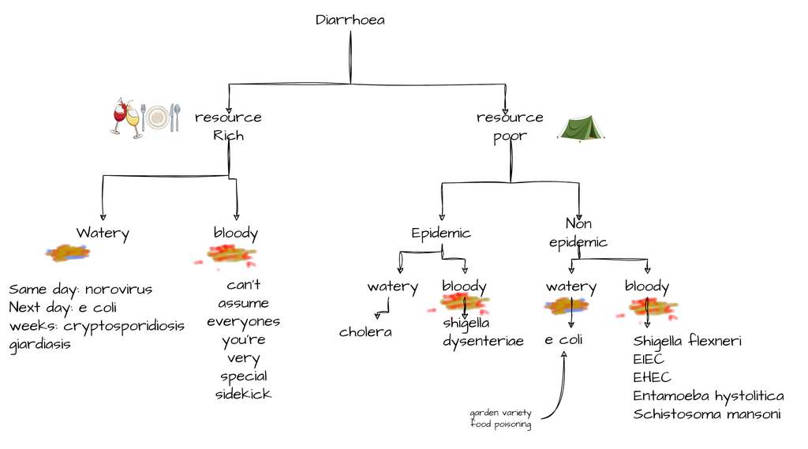

| **Infection** | **Typical presentation** |
| --- | --- |
| *Escherichia coli* | Common amongst travellers Watery stools Abdominal cramps and nausea |
| **Giardiasis** | Prolonged, non-bloody diarrhoea |
| **Cholera** | Profuse, watery diarrhoea Severe dehydration resulting in weight loss Not common amongst travellers |
| *Shigella* | *Bloody *diarrhoea Vomiting and abdominal pain |
| *Campylobacter* | A *flu-like prodrome* is usually followed by crampy abdominal pains, fever and diarrhoea which may be *bloody* May mimic appendicitis Complications include *Guillain-Barre syndrome* |
| **Amoebiasis** | Gradual onset *bloody* diarrhoea, abdominal pain and tenderness which may last for several weeks |
| *Staphylococcus aureus* | Severe *vomiting* Short incubation period |
| *Bacillus cereus* | Two types of illness are seen - vomiting within 6 hours, stereotypically due to rice - diarrhoeal illness occurring after 6 hours |

> [!INFO] Domains of MELD  
> Mnemonic: yellow (urine) + Green(bile) + Red (bleeding) (Red, Yellow, green)

[figure not shown]

[output not shown]

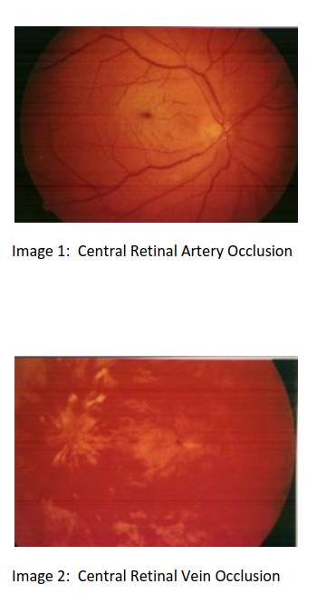

| Retinal artery occlusion (CRAO) | Retinal Venous occlusion (CRVO) |
| --- | --- |
| Less common | **Much more common** |
| Older population | older population |
| Urgent need of further evaluation | Doesn't need further evaluation for cause |
| Higher risk of ASCVD events |  |
| Managed by neurologist - like a stroke | Managed by **ophthalmologist** |
|  | Majority are managed conservatively. |
| Permanent renal death in a few hours. |  |
| Commonest causes are emboli: + ICA emobli + aortic arch, cardiac |  |
| Sudden vision loss (curtain coming down) | Vision loss ranges from slight to severe |
|  | **Retinal haemorrhages are common** |
| Vascular causes are the main risk factors | Age seems to be the main risk factor |
| **Retinal is pale, with prominent fovea** (cherry red spot) | Swollen disk with splotches of haemorrhage and cotton wool spots |
| Sudden (curtain coming down) | also sudden |

# Advanced life support (ALS / Resuscitation)

```
- Non shockable rhythm: ***Adrenaline 1mg ASAP*.** **(10ml of 1:10,000 IV or 1ml of 1:1000 IV)**
    - **NOTE: Adrenaline 1 in 1000 refers to 1mg / mL**
- Shockable rhythm: Adrenaline 1mg IV **AFTER THE 3RD SHOCK** (??adrenaline is delayed until 3rd shock due to arrhtyhmogenicity?)
```